# Solvers in R

Prof. Daniel P. Palomar

MAFS5310 - Portfolio Optimization with R MSc in Financial Mathematics The Hong Kong University of Science and Technology (HKUST) Fall 2022-23

This R session will introduce different solvers in R that can be used for portfolio optimization.

For an overwhelming amount of information on the many solvers for R, see the [Task View on Optimization and Mathematical Programming](https://cran.r-project.org/web/views/Optimization.html).

John Nash, the author of many of the optimization packages (not to be confused with the main character of the movie *A Beautiful Mind*), has an interesting and insightful blog: https://nashjc.wordpress.com. In particular, the entry on [choosing which method to use for “optimizing” functions](https://nashjc.wordpress.com/2016/11/20/choosing-which-method-to-use-for-optimizating-functions/) is recommended as a guide on how to navigate the overwhelming amount of solvers in R.

# General solvers

General solvers can deal with arbitrary nonlinear optimization problems, at the expense of perhaps slow convergence and risk of numerical issues.

## Package **stats**

Package **stats** (base R package installed by default) offers several general purpose optimization routines.

- `optimize()`: For one-dimensional unconstrained function optimization over an interval (for one-dimensional root finding use `uniroot()`).

```r
f <- function(x) exp(-0.5*x) * sin(10*pi*x)
f(0.5)
```

```
#> [1] 4.768779e-16
```

```r
result <- optimize(f, interval = c(0, 1), tol = 0.0001)
result
```

```
#> $minimum
#> [1] 0.3494978
#>
#> $objective
#> [1] -0.8395633
```

```r
str(result)
```

```
#> List of 2
#>  $ minimum  : num 0.349
#>  $ objective: num -0.84
```

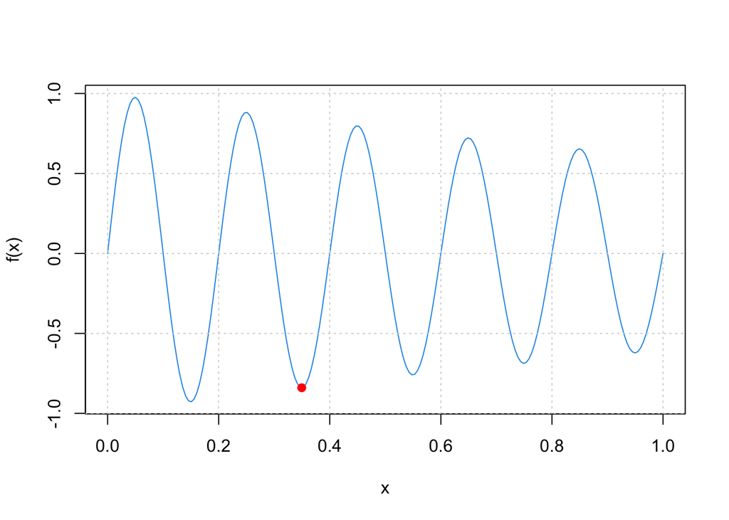

```r
# let's plot something
curve(f, 0, 1, n = 200, col = 4); grid()
points(result$minimum, result$objective, pch = 20, col = "red", cex = 1.5)
```

- `optim()`: General-purpose optimization with six different optimization methods (see [a conversation with the author](https://www.ibm.com/developerworks/library/ba-optimR-john-nash/index.html)):
  - `Nelder-Mead`: relatively robust method (default) that does not require derivatives (function `nmkb()` of package **dfoptim** is probably better)
  - `CG`: low-memory optimizer for unconstrained problems with high dimensions (albeit generally not satisfactory, better use package **Rcgmin**)
  - `BFGS`: simple unconstrained quasi-Newton method (package **Rvmmin** is probably better)
  - `L-BFGS-B`: modest-memory optimizer for bounds-constrained problems
  - `SANN`: simulated annealing method
  - `Brent`: for one-dimensional problems (it actually calls `optimize()`)

This example does a least squares fitting:
$$\begin{array}{ll}
\underset{a,b}{\textsf{minimize}} & \sum_{i=1}^{m} \left(y_i -
(a+bx_i)\right)^2
\end{array}$$

```r
# data points to be fitted
dat <- data.frame(x = c(1,2,3,4,5,6), y = c(1,3,5,6,8,12))

# squared l2-norm error of a linear fitting y ~ par[1] + par[2]*x
f <- function(param, data) sum((param[1] + param[2]*data$x - data$y)^2)

# call solver (with initial value c(0, 1) and default method = "Nelder-Mead")
result <- optim(par = c(0, 1), f, data = dat)
str(result)
```

```
#> List of 5
#>  $ par        : num [1:2] -1.27 2.03
#>  $ value      : num 2.82
#>  $ counts     : Named int [1:2] 89 NA
#>   ..- attr(*, "names")= chr [1:2] "function" "gradient"
#>  $ convergence: int 0
#>  $ message    : NULL
```

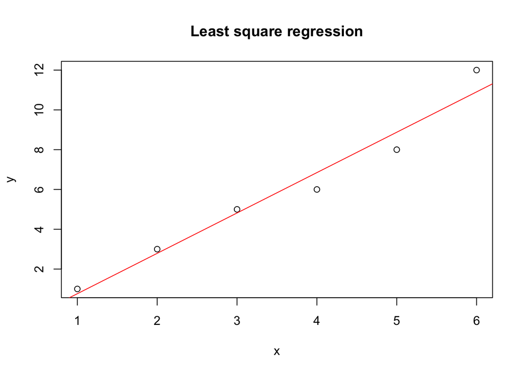

```r
# plot linear regression
plot(y ~ x, data = dat, main = "Least square regression")
abline(a = result$par[1], b = result$par[2], col = "red")
```

```r
# compare against the built in linear regression in R
lm(y ~ x, data = dat)
```

```
#>
#> Call:
#> lm(formula = y ~ x, data = dat)
#>
#> Coefficients:
#> (Intercept)            x
#>      -1.267        2.029
```

The next example illustrates the use of the gradient with the famous Rosenbrock banana function:
$$f(\mathbf{x}) = 100(x_2-x_1^2)^2 + (1-x_1)^2$$
with gradient
$$\nabla f(\mathbf{x}) = \left( \begin{array}{c}
-400x_1(x_2-x_1^2) -2(1-x_1)\\
200(x_2-x_1^2)
\end{array}\right)$$
with the unconstrained minimization problem
$$\begin{array}{ll}
\underset{\mathbf{x}\in \mathbf{R}^2}{\textsf{minimize}} &
100(x_2-x_1^2)^2 + (1-x_1)^2
\end{array}$$

```r
# Rosenbrock banana function and its gradient
f_banana <- function(x) 100 * (x[2] - x[1] * x[1])^2 + (1 - x[1])^2
gr_banana <- function(x)
    c(-400 * x[1] * (x[2] - x[1] * x[1]) - 2 * (1 - x[1]),
       200 * (x[2] - x[1] * x[1]))

res <- optim(c(-1.2, 1), f_banana)
str(res)
```

```
#> List of 5
#>  $ par        : num [1:2] 1 1
#>  $ value      : num 8.83e-08
#>  $ counts     : Named int [1:2] 195 NA
#>   ..- attr(*, "names")= chr [1:2] "function" "gradient"
#>  $ convergence: int 0
#>  $ message    : NULL
```

```r
res <- optim(c(-1.2, 1), f_banana, gr_banana, method = "BFGS")
str(res)
```

```
#> List of 5
#>  $ par        : num [1:2] 1 1
#>  $ value      : num 9.59e-18
#>  $ counts     : Named int [1:2] 110 43
#>   ..- attr(*, "names")= chr [1:2] "function" "gradient"
#>  $ convergence: int 0
#>  $ message    : NULL
```

The following example uses box constraints:
$$\begin{array}{ll}
\underset{\mathbf{x}\in \mathbf{R}^{25}}{\textsf{minimize}} & [1, 4,
4, \ldots, 4] \times
\left[ \begin{array}{c} (x_1-1^2)^2\\ (x_2-x_1^2)^2\\ (x_3-x_2^2)^2\\
\cdots\\ (x_{25}-x_{24}^2)^2\end{array}\right]\\
{\textsf{subject to}} & 2 \le x_i \le 4, \qquad i=1,\ldots,25
\end{array}$$

```r
flb <- function(x)
    { p <- length(x); sum(c(1, rep(4, p-1)) * (x - c(1, x[-p])^2)^2) }
# 25-dimensional box constrained
res <- optim(rep(3, 25), flb, NULL, method = "L-BFGS-B", lower = rep(2, 25), upper = rep(4, 25))
str(res)
```

```
#> List of 5
#>  $ par        : num [1:25] 2 2 2 2 2 2 2 2 2 2 ...
#>  $ value      : num 368
#>  $ counts     : Named int [1:2] 6 6
#>   ..- attr(*, "names")= chr [1:2] "function" "gradient"
#>  $ convergence: int 0
#>  $ message    : chr "CONVERGENCE: REL_REDUCTION_OF_F <= FACTR*EPSMCH"
```

This example uses the simulated annealing method (for global optimization):

```r
# "wild" function , global minimum at about -15.81515
f_wild <- function (x)
    10*sin(0.3*x)*sin(1.3*x^2) + 0.00001*x^4 + 0.2*x+80
plot(f_wild, -50, 50, n = 1000, main = "optim() minimizing 'wild function'")
res <- optim(50, f_wild, method = "SANN",
             control = list(maxit = 20000, temp = 20, parscale = 20))
str(res)
```

```
#> List of 5
#>  $ par        : num -15.8
#>  $ value      : num 67.5
#>  $ counts     : Named int [1:2] 20000 NA
#>   ..- attr(*, "names")= chr [1:2] "function" "gradient"
#>  $ convergence: int 0
#>  $ message    : NULL
```

```r
# now improve locally (typically only by a small bit):
res2 <- optim(res$par, f_wild, method = "BFGS")
str(res2)
```

```
#> List of 5
#>  $ par        : num -15.8
#>  $ value      : num 67.5
#>  $ counts     : Named int [1:2] 20 2
#>   ..- attr(*, "names")= chr [1:2] "function" "gradient"
#>  $ convergence: int 0
#>  $ message    : NULL
```

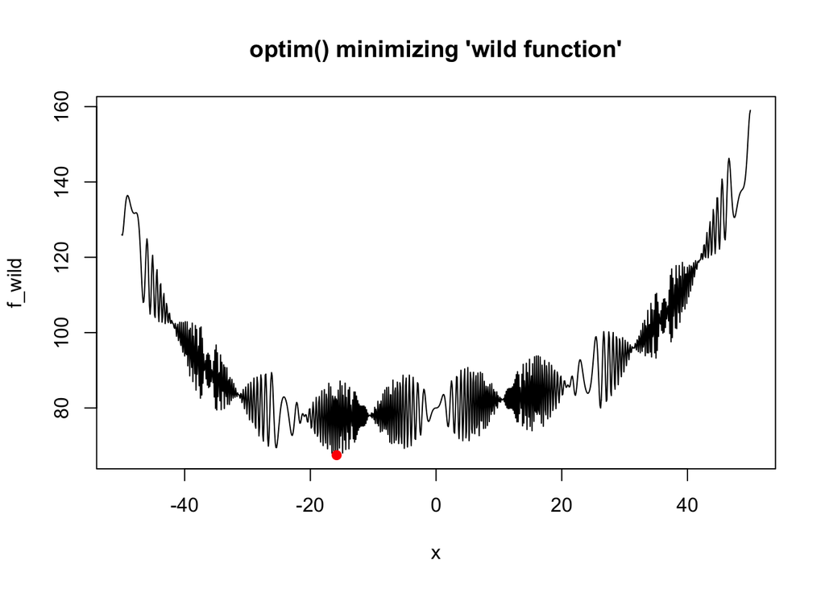

```r
points(res2$par, res2$value, pch = 20, col = "red", cex = 1.5)
```

- `constrOptim()`: Minimize a function subject to linear inequality constraints using an adaptive barrier algorithm (it calls `optim()` under the hood).

```r
#  inequality constraints (ui %*% theta >= ci): x <= 0.9,  y - x > 0.1
str(constrOptim(c(.5, 0), f_banana, gr_banana, ui = rbind(c(-1,0), c(1,-1)), ci = c(-0.9,0.1)))
```

```
#> List of 7
#>  $ par             : num [1:2] 0.889 0.789
#>  $ value           : num 0.0125
#>  $ counts          : Named num [1:2] 254 48
#>   ..- attr(*, "names")= chr [1:2] "function" "gradient"
#>  $ convergence     : int 0
#>  $ message         : NULL
#>  $ outer.iterations: int 4
#>  $ barrier.value   : num -7.4e-05
```

- `nlm()`: This function carries out a minimization of the objective function using a Newton-type algorithm.

```r
f <- function(x) sum((x - 1:length(x))^2)
res <- nlm(f, c(10,10))
str(res)
```

```
#> List of 5
#>  $ minimum   : num 4.3e-26
#>  $ estimate  : num [1:2] 1 2
#>  $ gradient  : num [1:2] 2.76e-13 -3.10e-13
#>  $ code      : int 1
#>  $ iterations: int 2
```

```r
res <- nlm(f, c(10,10), print.level = 2)
```

```
#> iteration = 0
#> Step:
#> [1] 0 0
#> Parameter:
#> [1] 10 10
#> Function Value
#> [1] 145
#> Gradient:
#> [1] 18.00001 16.00001
#>
#> iteration = 1
#> Step:
#> [1] -9 -8
#> Parameter:
#> [1] 1 2
#> Function Value
#> [1] 1.721748e-13
#> Gradient:
#> [1] 1.551336e-06 1.379735e-06
#>
#> iteration = 2
#> Parameter:
#> [1] 1 2
#> Function Value
#> [1] 4.303458e-26
#> Gradient:
#> [1]  2.757794e-13 -3.099743e-13
#>
#> Relative gradient close to zero.
#> Current iterate is probably solution.
```

```r
str(res)
```

```
#> List of 5
#>  $ minimum   : num 4.3e-26
#>  $ estimate  : num [1:2] 1 2
#>  $ gradient  : num [1:2] 2.76e-13 -3.10e-13
#>  $ code      : int 1
#>  $ iterations: int 2
```

- `nlminb()`: Unconstrained and box-constrained optimization using PORT routines.

```r
res <- nlminb(c(-1.2, 1), f_banana)
str(res)
```

```
#> List of 6
#>  $ par        : num [1:2] 1 1
#>  $ objective  : num 2.77e-20
#>  $ convergence: int 0
#>  $ iterations : int 35
#>  $ evaluations: Named int [1:2] 44 74
#>   ..- attr(*, "names")= chr [1:2] "function" "gradient"
#>  $ message    : chr "X-convergence (3)"
```

```r
res2 <- nlminb(c(-1.2, 1), f_banana, gr_banana)
str(res2)
```

```
#> List of 6
#>  $ par        : num [1:2] 1 1
#>  $ objective  : num 4.29e-22
#>  $ convergence: int 0
#>  $ iterations : int 35
#>  $ evaluations: Named int [1:2] 43 36
#>   ..- attr(*, "names")= chr [1:2] "function" "gradient"
#>  $ message    : chr "X-convergence (3)"
```

## Package **optimr**

The author of the base function `optim()` (which he claims is obsolete now) has also created the package **optimr** as a convenient wrapper to many other solvers so that they can be easily used and compared:

```r
library(optimr)  # install.packages("optimr")

# optimr() can be called like optim() but has more methods: "Nelder-Mead", "BFGS", "CG", "L-BFGS-B", "nlm", "nlminb", "Rcgmin", "Rvmmin", and "hjn"
res <- optimr(c(-1.2, 1), f_banana, method = "Rvmmin")
str(res)
```

```
#> List of 5
#>  $ par        : num [1:2] -0.855 1.141
#>  $ value      : num 20.2
#>  $ counts     : Named num [1:2] 30 2
#>   ..- attr(*, "names")= chr [1:2] "function" "gradient"
#>  $ convergence: num 3
#>  $ message    : chr "Rvmminu appears to have converged"
```

```r
res <- optimr(c(-1.2, 1), f_banana, gr_banana, method = "Rvmmin")
str(res)
```

```
#> List of 5
#>  $ par        : num [1:2] 1 1
#>  $ value      : num 1.23e-32
#>  $ counts     : Named num [1:2] 59 39
#>   ..- attr(*, "names")= chr [1:2] "function" "gradient"
#>  $ convergence: num 2
#>  $ message    : chr "Rvmminu appears to have converged"
```

```r
# opm() can use several methods at the same time
res <- opm(c(-1.2, 1), f_banana, method = c("Nelder-Mead", "BFGS"))
print(res)
```

```
#>                    p1        p2        value fevals gevals convergence  kkt1 kkt2 xtime
#> Nelder-Mead 1.0002601 1.0005060 8.825241e-08    195     NA           0 FALSE TRUE     0
#> BFGS        0.9998044 0.9996084 3.827383e-08    118     38           0  TRUE TRUE     0
```

```r
res <- opm(c(-1.2, 1), f_banana, gr_banana, control = list(all.methods = TRUE))
print(res)
```

```
#>                    p1        p2        value fevals gevals convergence  kkt1 kkt2 xtime
#> BFGS        1.0000000 1.0000000 9.594956e-18    110     43           0  TRUE TRUE 0.000
#> CG          0.9174130 0.8413632 6.802745e-03   3957   1001           1 FALSE TRUE 0.003
#> Nelder-Mead 1.0002601 1.0005060 8.825241e-08    195     NA           0 FALSE TRUE 0.000
#> L-BFGS-B    0.9999997 0.9999995 2.267577e-13     47     47           0  TRUE TRUE 0.001
#> nlm         1.0000000 1.0000000 1.182096e-20     NA     24           0  TRUE TRUE 0.000
#> nlminb      1.0000000 1.0000000 4.291816e-22     43     36           0  TRUE TRUE 0.001
#> Rcgmin      1.0000000 1.0000000 8.843379e-18    735    434           0  TRUE TRUE 0.005
#> Rvmmin      1.0000000 1.0000000 1.232595e-32     59     39           2  TRUE TRUE 0.002
#> hjn         1.0000009 1.0000018 8.493464e-13    865     NA           0  TRUE TRUE 0.003
```

The package **optimrx** is similar to **optimr** but accepts more methods. It is not available in CRAN, instead check [R-Forge](https://rdrr.io/rforge/optimrx/) and to install do: `install.packages("optimrx", repos="http://R-Forge.R-project.org")`.

## Package **gloptim**

Package **gloptim** is a wrapper to many global optimization packages (similar in spirit to what **optimr** is lo local optimization). Note that global optimization is totally different in philosophy to local optimization (global optimization solvers are usually called stochastic solvers and attempt to escape local optimum points). To install, do: `install.packages("gloptim", repos="http://R-Forge.R-project.org")`.

# Solvers for specific classes of problems

If the problem to be solved falls within a particular class of problems, such as LS, LP, MILP, QP, SOCP, or SDP, then it is much better to use a solver specific for that class.

## Least Squares (LS)

A linear least-squares (LS) problem minimizes the $\ell_2$-norm $\|\mathbf{A}\mathbf{x}-\mathbf{b}\|_2$ possibly with bounds or linear constraints. The function `qr.solve(A, b)` from base R solves over- and underdetermined linear systems in the least-squares sense. The package **colf** performs least squares constrained optimization on a linear objective function and contains a number of algorithms to choose from.

## Linear Programming (LP)

The package **linprog** contains the function `solveLP()` to conveniently solve LPs of the form:
$$\begin{array}{ll}
\underset{\mathbf{x}\in \mathbf{R}^n}{\textsf{minimize}} &
\mathbf{c}^T\mathbf{x}\\
{\textsf{subject to}} & \begin{array}[t]{l} \mathbf{A}\mathbf{x} \le
\mathbf{b}\\
\mathbf{x} \ge \mathbf{0}\end{array}\\
\end{array}$$

```r
library(linprog)  # install.packages("linprog")
# example of Steinhauser, Langbehn and Peters (1992)
cvec <- c(1800, 600, 600)  # gross margins
names(cvec) <- c("Cows", "Bulls", "Pigs")
bvec <- c(40, 90, 2500)  # endowment
names(bvec) <- c("Land", "Stable", "Labor")
Amat <- rbind(c(0.7, 0.35, 0),
              c( 1.5, 1, 3),
              c( 50, 12.5, 20))
# run solver
res <- solveLP(cvec, bvec, Amat, maximum = TRUE)
print(res)
```

```
#>
#>
#> Results of Linear Programming / Linear Optimization
#>
#> Objective function (Maximum): 93600
#>
#> Iterations in phase 1: 0
#> Iterations in phase 2: 2
#> Solution
#>       opt
#> Cows   44
#> Bulls  24
#> Pigs    0
#>
#> Basic Variables
#>         opt
#> Cows   44.0
#> Bulls  24.0
#> S Land  0.8
#>
#> Constraints
#>        actual dir bvec free  dual dual.reg
#> Land     39.2  <=   40  0.8   0.0      0.8
#> Stable   90.0  <=   90  0.0 240.0     15.0
#> Labor  2500.0  <= 2500  0.0  28.8   1375.0
#>
#> All Variables (including slack variables)
#>           opt cvec min.c    max.c   marg marg.reg
#> Cows     44.0 1800   900 2400.000     NA       NA
#> Bulls    24.0  600   450 1200.000     NA       NA
#> Pigs      0.0  600  -Inf 1296.000 -696.0     6.25
#> S Land    0.8    0    NA  731.092    0.0       NA
#> S Stable  0.0    0  -Inf  240.000 -240.0    15.00
#> S Labor   0.0    0  -Inf   28.800  -28.8  1375.00
```

## Mixed Integer Linear Programming (MILP)

The package **lpSolve** (much faster than **linprog** because it is coded in C) solves linear mixed integer problems (i.e., LPs possibly with some integer constraints):

```r
library(lpSolve)  # install.packages("lpSolve")

# Set up problem:
#   maximize      x1 + 9 x2 + x3
#   subject to    x1 + 2 x2 + 3 x3 <= 9
#               3 x1 + 2 x2 + 2 x3 <= 15
f.obj <- c(1, 9, 1)
f.con <- matrix(c(1, 2, 3, 3, 2, 2), nrow = 2, byrow = TRUE)
f.dir <- c("<=", "<=")
f.rhs <- c(9, 15)

# run solver
res <- lp("max", f.obj, f.con, f.dir, f.rhs)
print(res)
```

```
#> Success: the objective function is 40.5
```

```r
res$solution
```

```
#> [1] 0.0 4.5 0.0
```

```r
# run again, this time requiring that all three variables be integer
res_int <- lp("max", f.obj, f.con, f.dir, f.rhs, int.vec = 1:3)
print(res_int)
```

```
#> Success: the objective function is 37
```

```r
res_int$solution
```

```
#> [1] 1 4 0
```

Another good package is **Rglpk**, which is an R interface to the GNU Linear Programming Kit. ‘GLPK’ is open source software for solving large-scale LP, MILP, and other related problems.

## Quadratic Programming (QP)

The package **quadprog** contains the function `solve.QP()` to conveniently solve QPs of the form:
$$\begin{array}{ll}
\underset{\mathbf{x}\in \mathbf{R}^n}{\textsf{minimize}} &
-\mathbf{d}^T\mathbf{x} + \frac{1}{2}\mathbf{x}^T\mathbf{D}\mathbf{x}\\
{\textsf{subject to}} & \mathbf{A}^T\mathbf{x} =/\ge \mathbf{b}\\
\end{array}$$

```r
library(quadprog)  # install.packages("quadprog")

# Set up problem:
#   minimize    -(0 5 0) %*% x + 1/2 x^T x
#   subject to  A^T x >= b
#   with b = (-8,2,0)^T
#       (-4 2  0)
#   A = (-3 1 -2)
#       ( 0 0  1)
Dmat <- diag(3)
dvec <- c(0, 5, 0)
Amat <- matrix(c(-4, -3, 0, 2, 1, 0, 0, -2, 1), 3, 3)
bvec <- c(-8, 2, 0)

# run solver
res <- solve.QP(Dmat, dvec, Amat, bvec)
str(res)
```

```
#> List of 6
#>  $ solution              : num [1:3] 0.476 1.048 2.095
#>  $ value                 : num -2.38
#>  $ unconstrained.solution: num [1:3] 0 5 0
#>  $ iterations            : int [1:2] 3 0
#>  $ Lagrangian            : num [1:3] 0 0.238 2.095
#>  $ iact                  : int [1:2] 3 2
```

The package **quadprogXT** extends the **quadprog** to solve quadratic programs with absolute value constraints and absolute values in the objective function.

## Second-Order Cone Programming (SOCP)

There are several packages:

- Package **ECOSolveR** provides an interface to the [Embedded COnic Solver (ECOS)](http://www.embotech.com/ECOS), a well-known, efficient, and robust C library for convex problems. Conic and equality constraints can be specified in addition to integer and boolean variable constraints for mixed-integer problems.
- The **CLSOCP** package provides an implementation of a one-step smoothing Newton method for the solution of SOCP problems.

## Cone Programming and Semi-Definite Programming (SDP)

There are several good packages:

- Package **scs** applies operator splitting to solve linear programs, cone programs (SOCP), and semidefinite programs; cones can be second-order, exponential, power cones, or any combination of these.
- Package **sdpt3r** solves general semidefinite programs using an R implementation of SDPT3, a MATLAB software for semidefinite quadratic-linear programming.
- Package **Rcsdp** is an interface to the CSDP semidefinite programming library of routines that implement a primal-dual barrier method for solving semidefinite programming problems.
- Package **Rmosek** provides an interface to the (commercial) [MOSEK](https://www.mosek.com/) optimization library for large-scale LP, QP, and MIP problems, with emphasis on (nonlinear) conic, semidefinite, and convex tasks; academic licenses are available.

# Optimization infrastructure packages

We have already seen two packages that are wrappers to many other solvers, namely: **optimr** for local optimization and **gloptim** for global optimization.

It is also worth mentioning the [NEOS Server](https://neos-server.org/neos/) for optimization that provides online access to state-of-the-art optimization problem solvers. It is a free internet-based service for solving numerical optimization problems and provides access to more than 60 state-of-the-art solvers. The R package **rneos** enables the user to pass optimization problems to NEOS and retrieve results within R.

The following two packages are extremely useful and powerful: **ROI** and **CVXR**.